# Bike Share Ride Analysis

Avinash Ganesh

2024-05-15

## Problem Background

### Introduction

- The Cyclistic bike-share analysis case study is my Google Data Analytics Capstone Project where I work for a fictional company, Cyclistic and follow the steps of the data analysis process (Ask, Prepare, Process, Analyze, Share, Act) to answer business questions. The scenario is described as follows:
  - Acting as a data analyst working on the marketing analyst team at Cyclistic, a bike-share company in Chicago.
  - Director of marketing believes that company’s future success depends on maximizing the number of annual memberships.
  - Analytics team must understand how casual riders and annual members use Cyclistic bikes differently.
  - The team will design a new marketing strategy to convert casual riders into annual members using compelling data insights and professional data visualizations

### Characters and Teams

- Cyclistic
  - A bike-share program that features more than 5,800 bicycles and 600 docking stations.
  - Cyclistic sets itself apart by also offering reclining bikes, hand tricycles, and cargo bikes, making bike-share more inclusive to people with disabilities and riders who can’t use a standard two-wheeled bike.
  - Majority of riders opt for traditional bikes; about 8% of riders use the assistive options. Users more likely to ride for leisure, but about 30% use bikes to commute to work everyday.
- Lily Moreno
  - Director of marketing and responsible for development of campaigns and initiatives to promote the bike-share program through email, social media, and other channels.
- Cyclistic Marketing Analytics Team
  - Team of data analysts who are responsible for collecting, analyzing, and reporting data that helps guide marketing strategy.
- Cyclistic Executive Team
  - Detail-oriented executive team that will decide to approve the recommended marketing program.

## Data Analysis

### Ask: A clear statement of the business task

- Three questions will guide the future marketing program:
  - How do annual members and casual riders use Cyclistic bikes differently?
  - Why would casual riders buy Cyclisitic annual memberships?
  - How can Cyclisitic use digital media to influence casual riders to become members?
- Business Task
  - The business task is to analyze the usage patterns of casual riders and annual members of Cyclisitic bikes in Chicago to identify key differences in their behavior. These insights will inform the development of a targeted marketing strategy aimed at converting casual riders into annual members, ultimately maximizing the number of annual memberships and driving the company’s future success.

### Prepare: A description of all data sources used

- Download the data and store it appropriately
  - Data downloaded from this [link](https://divvy-tripdata.s3.amazonaws.com/index.html), and stored on local PC.
  - Data downloaded from December 2023 - April 2024
- Imported the appropriate libraries for use

```r
library(tidyverse)
```

```r
library(readr)
library(ggplot2)
```

- Identified the data and organized all data sources

```r
# Specify the file path to CSV file
jan2024_data_file_path <- "C:/Users/Owner/Downloads/202312-divvy-tripdata/202312-divvy-tripdata.csv"
feb2024_data_file_path <- "C:/Users/Owner/Downloads/202401-divvy-tripdata/202401-divvy-tripdata.csv"
mar2024_data_file_path <- "C:/Users/Owner/Downloads/202402-divvy-tripdata/202402-divvy-tripdata.csv"
apr2024_data_file_path <- "C:/Users/Owner/Downloads/202403-divvy-tripdata/202403-divvy-tripdata.csv"
may2024_data_file_path <- "C:/Users/Owner/Downloads/202404-divvy-tripdata/202404-divvy-tripdata.csv"

# Read CSV file into a data frame
jan2024_data <- read.csv(jan2024_data_file_path)
feb2024_data <- read.csv(feb2024_data_file_path)
mar2024_data <- read.csv(mar2024_data_file_path)
apr2024_data <- read.csv(apr2024_data_file_path)
may2024_data <- read.csv(may2024_data_file_path)

# Combine into 1 file
trip_data <- bind_rows(jan2024_data, feb2024_data, mar2024_data, apr2024_data, may2024_data)

# Inspect data
colnames(trip_data) # List of column names
```

```
##  [1] "ride_id"            "rideable_type"      "started_at"
##  [4] "ended_at"           "start_station_name" "start_station_id"
##  [7] "end_station_name"   "end_station_id"     "start_lat"
## [10] "start_lng"          "end_lat"            "end_lng"
## [13] "member_casual"
```

```r
dim(trip_data) # Dimensions of data frame
```

```
## [1] 1308822      13
```

```r
head(trip_data) # First 6 rows of data frame
```

```
##            ride_id rideable_type          started_at            ended_at
## 1 C9BD54F578F57246 electric_bike 2023-12-02 18:44:01 2023-12-02 18:47:51
## 2 CDBD92F067FA620E electric_bike 2023-12-02 18:48:19 2023-12-02 18:54:48
## 3 ABC0858E52CBFC84 electric_bike 2023-12-24 01:56:32 2023-12-24 02:04:09
## 4 F44B6F0E8F76DC90 electric_bike 2023-12-24 10:58:12 2023-12-24 11:03:04
## 5 3C876413281A90DF electric_bike 2023-12-24 12:43:16 2023-12-24 12:44:57
## 6 28C0D6EFB81E1769 electric_bike 2023-12-24 13:59:57 2023-12-24 14:10:57
##   start_station_name start_station_id end_station_name end_station_id start_lat
## 1                                                                         41.92
## 2                                                                         41.92
## 3                                                                         41.89
## 4                                                                         41.95
## 5                                                                         41.92
## 6                                                                         41.91
##   start_lng end_lat end_lng member_casual
## 1    -87.66   41.92  -87.66        member
## 2    -87.66   41.89  -87.64        member
## 3    -87.62   41.90  -87.64        member
## 4    -87.65   41.94  -87.65        member
## 5    -87.64   41.93  -87.64        member
## 6    -87.63   41.88  -87.65        member
```

```r
tail(trip_data) # Last 6 rows of data frame
```

```
##                  ride_id rideable_type          started_at            ended_at
## 1308817 5CE1D1529C834AD3 electric_bike 2024-04-06 09:27:18 2024-04-06 09:38:11
## 1308818 5E41443305C3B8A0  classic_bike 2024-04-06 13:40:56 2024-04-07 14:40:49
## 1308819 50A275230D6C0492  classic_bike 2024-04-01 19:03:43 2024-04-01 19:13:16
## 1308820 A88F756403FBF27F electric_bike 2024-04-11 16:09:50 2024-04-11 16:26:07
## 1308821 DFD402AC5915F136 electric_bike 2024-04-19 07:20:28 2024-04-19 07:30:05
## 1308822 61F035E8DCBB5313 electric_bike 2024-04-16 15:53:32 2024-04-16 16:15:20
##                   start_station_name start_station_id
## 1308817       Clark St & Lincoln Ave            13179
## 1308818       Clark St & Lincoln Ave            13179
## 1308819   California Ave & Cortez St            17660
## 1308820 Clinton St & Washington Blvd           WL-012
## 1308821 Clinton St & Washington Blvd           WL-012
## 1308822 Clinton St & Washington Blvd           WL-012
##                       end_station_name end_station_id start_lat start_lng
## 1308817                                                41.91579 -87.63458
## 1308818                                                41.91569 -87.63460
## 1308819 California Ave & Milwaukee Ave          13084  41.90036 -87.69670
## 1308820                                                41.88350 -87.64158
## 1308821                                                41.88317 -87.64113
## 1308822                                                41.88339 -87.64122
##          end_lat   end_lng member_casual
## 1308817 41.94000 -87.64000        member
## 1308818       NA        NA        casual
## 1308819 41.92269 -87.69715        member
## 1308820 41.91000 -87.68000        member
## 1308821 41.89000 -87.62000        member
## 1308822 41.92000 -87.66000        member
```

```r
str(trip_data) # Structure of data frame
```

```
## 'data.frame':    1308822 obs. of  13 variables:
##  $ ride_id           : chr  "C9BD54F578F57246" "CDBD92F067FA620E" "ABC0858E52CBFC84" "F44B6F0E8F76DC90" ...
##  $ rideable_type     : chr  "electric_bike" "electric_bike" "electric_bike" "electric_bike" ...
##  $ started_at        : chr  "2023-12-02 18:44:01" "2023-12-02 18:48:19" "2023-12-24 01:56:32" "2023-12-24 10:58:12" ...
##  $ ended_at          : chr  "2023-12-02 18:47:51" "2023-12-02 18:54:48" "2023-12-24 02:04:09" "2023-12-24 11:03:04" ...
##  $ start_station_name: chr  "" "" "" "" ...
##  $ start_station_id  : chr  "" "" "" "" ...
##  $ end_station_name  : chr  "" "" "" "" ...
##  $ end_station_id    : chr  "" "" "" "" ...
##  $ start_lat         : num  41.9 41.9 41.9 42 41.9 ...
##  $ start_lng         : num  -87.7 -87.7 -87.6 -87.7 -87.6 ...
##  $ end_lat           : num  41.9 41.9 41.9 41.9 41.9 ...
##  $ end_lng           : num  -87.7 -87.6 -87.6 -87.7 -87.6 ...
##  $ member_casual     : chr  "member" "member" "member" "member" ...
```

```r
summary(trip_data) # Statistical summary of data
```

```
##    ride_id          rideable_type       started_at          ended_at
##  Length:1308822     Length:1308822     Length:1308822     Length:1308822
##  Class :character   Class :character   Class :character   Class :character
##  Mode  :character   Mode  :character   Mode  :character   Mode  :character
##
##
##
##
##  start_station_name start_station_id   end_station_name   end_station_id
##  Length:1308822     Length:1308822     Length:1308822     Length:1308822
##  Class :character   Class :character   Class :character   Class :character
##  Mode  :character   Mode  :character   Mode  :character   Mode  :character
##
##
##
##
##    start_lat       start_lng         end_lat         end_lng
##  Min.   :41.65   Min.   :-87.89   Min.   :41.63   Min.   :-87.96
##  1st Qu.:41.88   1st Qu.:-87.66   1st Qu.:41.88   1st Qu.:-87.66
##  Median :41.90   Median :-87.64   Median :41.90   Median :-87.64
##  Mean   :41.90   Mean   :-87.65   Mean   :41.90   Mean   :-87.65
##  3rd Qu.:41.93   3rd Qu.:-87.63   3rd Qu.:41.93   3rd Qu.:-87.63
##  Max.   :42.07   Max.   :-87.53   Max.   :42.15   Max.   :-87.46
##                                   NA's   :1720    NA's   :1720
##  member_casual
##  Length:1308822
##  Class :character
##  Mode  :character
##
##
##
##
```

```r
View(trip_data) # View the data frame
```

### Process: Documentation of any cleaning or manipulation of data

- Check the data for errors, empty strings, NA values

```r
# Replace empty strings with NA
trip_data[trip_data == ""] <- NA

# Keep only the rows with no NA values
trip_datav2 <- trip_data[complete.cases(trip_data), ]
```

- Added additional columns to provide opportunities to aggregate data

```r
# Adding additional columns of data (date, day, month, year, day of week) for data aggregation
trip_datav2$date <- as.Date(trip_datav2$started_at)
trip_datav2$month <- format(as.Date(trip_datav2$date), "%m")
trip_datav2$day <- format(as.Date(trip_datav2$date), "%d")
trip_datav2$year <- format(as.Date(trip_datav2$date), "%Y")
trip_datav2$day_of_week <- format(as.Date(trip_datav2$date), "%A")
```

- Added additional column to compute ride duration, and removed rows that had a negative ride duration

```r
# Add a column that computes the ride length
trip_datav2$ride_length <- difftime(trip_datav2$ended_at, trip_datav2$started_at)
trip_datav2$ride_length <- as.numeric(as.character(trip_datav2$ride_length)) # Convert to numeric
str(trip_datav2)
```

```
## 'data.frame':    993763 obs. of  19 variables:
##  $ ride_id           : chr  "84BFC1F137684EAB" "EEC92D30A70471E5" "1C33464DEEB1F23C" "E0A61810C305E5EC" ...
##  $ rideable_type     : chr  "classic_bike" "classic_bike" "electric_bike" "classic_bike" ...
##  $ started_at        : chr  "2023-12-02 23:12:51" "2023-12-14 13:43:14" "2023-12-04 11:57:04" "2023-12-04 09:34:22" ...
##  $ ended_at          : chr  "2023-12-02 23:21:01" "2023-12-14 13:44:14" "2023-12-04 12:13:59" "2023-12-04 09:35:56" ...
##  $ start_station_name: chr  "DuSable Museum" "California Ave & Division St" "Chicago State University" "Cottage Grove Ave & 51st St" ...
##  $ start_station_id  : chr  "KA1503000075" "13256" "20106" "TA1309000067" ...
##  $ end_station_name  : chr  "Cottage Grove Ave & 51st St" "California Ave & Division St" "Chicago State University" "Cottage Grove Ave & 51st St" ...
##  $ end_station_id    : chr  "TA1309000067" "13256" "20106" "TA1309000067" ...
##  $ start_lat         : num  41.8 41.9 41.7 41.8 41.8 ...
##  $ start_lng         : num  -87.6 -87.7 -87.6 -87.6 -87.6 ...
##  $ end_lat           : num  41.8 41.9 41.7 41.8 41.8 ...
##  $ end_lng           : num  -87.6 -87.7 -87.6 -87.6 -87.6 ...
##  $ member_casual     : chr  "member" "casual" "casual" "casual" ...
##  $ date              : Date, format: "2023-12-02" "2023-12-14" ...
##  $ month             : chr  "12" "12" "12" "12" ...
##  $ day               : chr  "02" "14" "04" "04" ...
##  $ year              : chr  "2023" "2023" "2023" "2023" ...
##  $ day_of_week       : chr  "Saturday" "Thursday" "Monday" "Monday" ...
##  $ ride_length       : num  490 60 1015 94 13 ...
```

```r
# Delete negative trip duration rows
trip_datav3 <- trip_datav2[!(trip_datav2$ride_length<0), ]
```

### Analyze: A summary of analysis

- Outputted basic statistical analysis of ride durations and compared both user types (members vs casual)

```r
# Statistical analysis of ride length
summary(trip_datav3$ride_length)
```

```
##    Min. 1st Qu.  Median    Mean 3rd Qu.    Max.
##     0.0   305.0   518.0   845.4   910.0 89859.0
```

```r
# Compare members and casual users
aggregate(trip_datav3$ride_length ~ trip_datav3$member_casual, FUN = mean)
```

```
##   trip_datav3$member_casual trip_datav3$ride_length
## 1                    casual               1287.1884
## 2                    member                697.4786
```

```r
aggregate(trip_datav3$ride_length ~ trip_datav3$member_casual, FUN = median)
```

```
##   trip_datav3$member_casual trip_datav3$ride_length
## 1                    casual                     675
## 2                    member                     480
```

```r
aggregate(trip_datav3$ride_length ~ trip_datav3$member_casual, FUN = max)
```

```
##   trip_datav3$member_casual trip_datav3$ride_length
## 1                    casual                   89613
## 2                    member                   89859
```

```r
aggregate(trip_datav3$ride_length ~ trip_datav3$member_casual, FUN = min)
```

```
##   trip_datav3$member_casual trip_datav3$ride_length
## 1                    casual                       0
## 2                    member                       0
```

- Aggregated data to analyze average ride duration per weekday by user type

```r
# See average ride time by each day for members vs casual users
aggregate(trip_datav3$ride_length ~ trip_datav3$member_casual + trip_datav3$day_of_week, FUN = mean)
```

```
##    trip_datav3$member_casual trip_datav3$day_of_week trip_datav3$ride_length
## 1                     casual                  Friday               1133.5888
## 2                     member                  Friday                657.7261
## 3                     casual                  Monday               1297.7279
## 4                     member                  Monday                689.5091
## 5                     casual                Saturday               1483.8263
## 6                     member                Saturday                767.2505
## 7                     casual                  Sunday               1594.1287
## 8                     member                  Sunday                769.9813
## 9                     casual                Thursday                970.6707
## 10                    member                Thursday                660.2128
## 11                    casual                 Tuesday               1190.2473
## 12                    member                 Tuesday                698.0214
## 13                    casual               Wednesday               1055.3291
## 14                    member               Wednesday                677.2748
```

```r
# Fix order to make days of the week in order
trip_datav3$day_of_week <- ordered(trip_datav3$day_of_week, levels = c("Sunday", "Monday", "Tuesday",
                                                                       "Wednesday", "Thursday", "Friday",
                                                                       "Saturday"))
# Re-run aggregate
aggregate(trip_datav3$ride_length ~ trip_datav3$member_casual + trip_datav3$day_of_week, FUN = mean)
```

```
##    trip_datav3$member_casual trip_datav3$day_of_week trip_datav3$ride_length
## 1                     casual                  Sunday               1594.1287
## 2                     member                  Sunday                769.9813
## 3                     casual                  Monday               1297.7279
## 4                     member                  Monday                689.5091
## 5                     casual                 Tuesday               1190.2473
## 6                     member                 Tuesday                698.0214
## 7                     casual               Wednesday               1055.3291
## 8                     member               Wednesday                677.2748
## 9                     casual                Thursday                970.6707
## 10                    member                Thursday                660.2128
## 11                    casual                  Friday               1133.5888
## 12                    member                  Friday                657.7261
## 13                    casual                Saturday               1483.8263
## 14                    member                Saturday                767.2505
```

- Create a subset of the cleaned data frame that contains user type, weekday, total ride count, and average ride duration

```r
# Analyze ridership data by type and weekday
analyze_by_type_weekday <- trip_datav3 %>%
  mutate(weekday = wday(started_at, label = TRUE)) %>% # Creates weekday field using wday()
  group_by(member_casual, weekday) %>% # Groups by user type and weekday
  summarise(number_of_rides = n()
            ,average_duration = mean(ride_length)) %>% # Calculates number of rides and average duration
  arrange(member_casual, weekday) # Sorts
View(analyze_by_type_weekday)
```

### Share: Supporting visualiziations and key findings

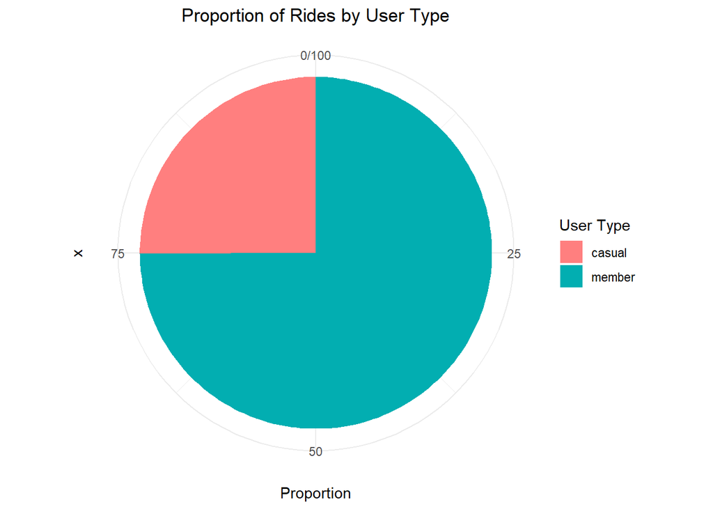

- A bar chart was created to visualize the total number of rides taken per weekday for each type of user. This chart reveals that annual members outnumber casual members on every day of the week by a large margin, except on weekends.
  - This is aligned with the thinking that most members use it for everyday use and therefore have a more consistent amount of rides per day. It also aligns with the idea that casual members are often using it more on the weekends, when they are more available.

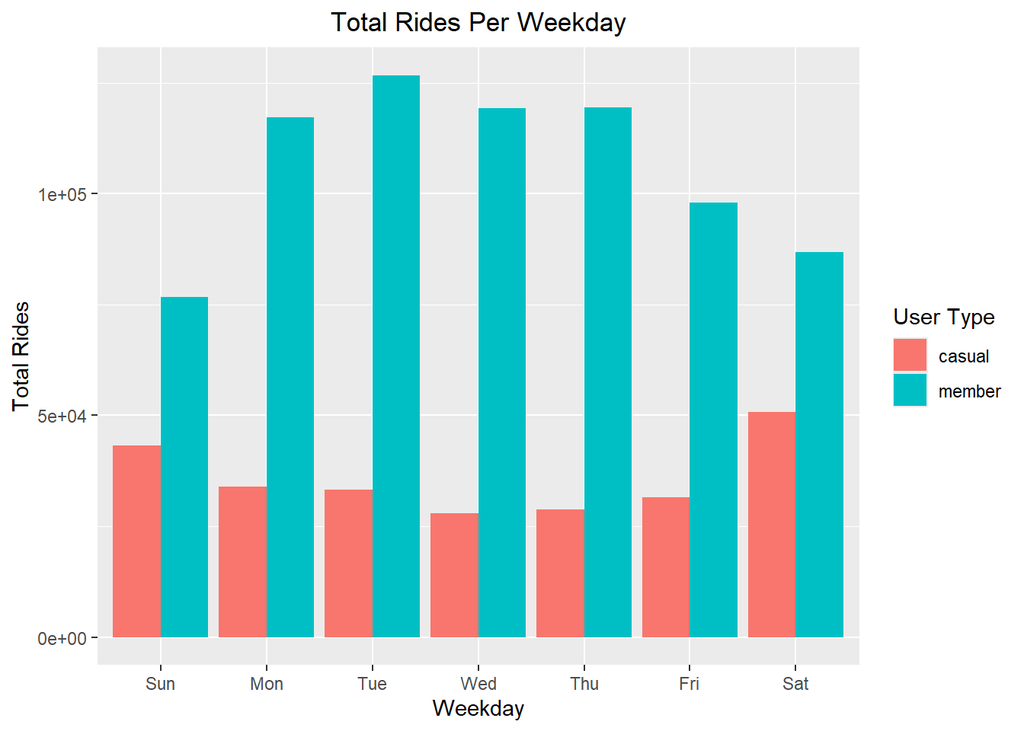

- A bar chart was created to visualize the average ride duration per weekday for each type of user. This chart reveals that the average ride duration for casual members is higher than the annual members on every day of the week by a large margin.
  - This discovery is aligned with the idea that casual members may be using the bike share to explore the area rather than to commute places.

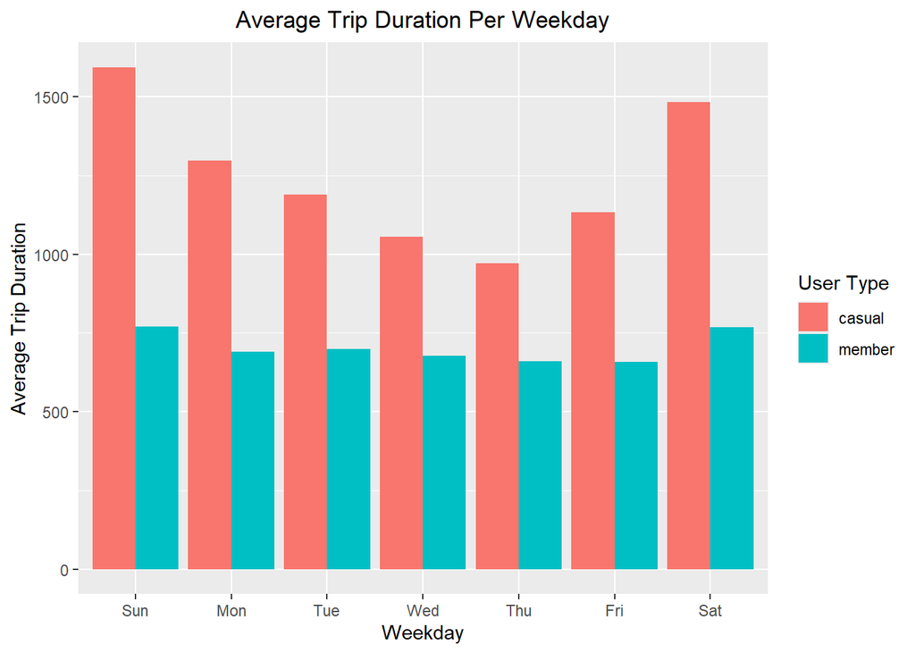

- Two additional bar charts were generated to identify popular start stations and popular end stations, in order to identify key locations where marketing efforts could be focused to influence casual members to become annual members.

- The data reveals that 9/10 of the top 10 most popular start and end stations are the same, with the top 8 being exactly identical. This suggests that these are high traffic areas for Cyclistic to develop targeted strategies that address the specific needs and preferences of casual riders, to increase the likelihood of successful conversion to annual memberships.

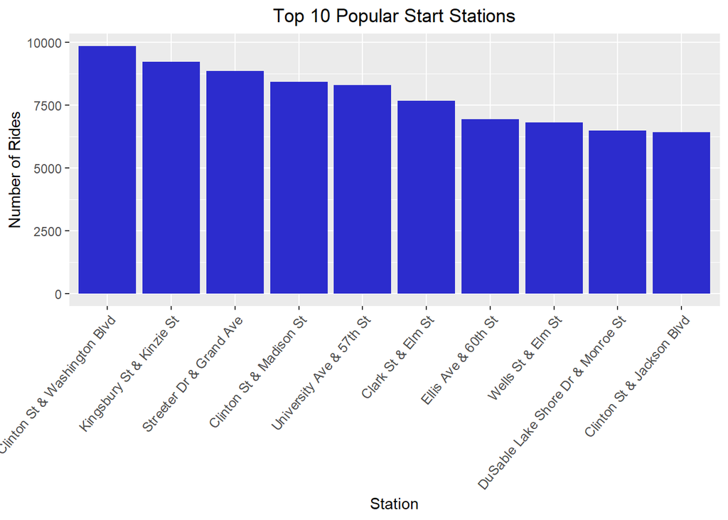

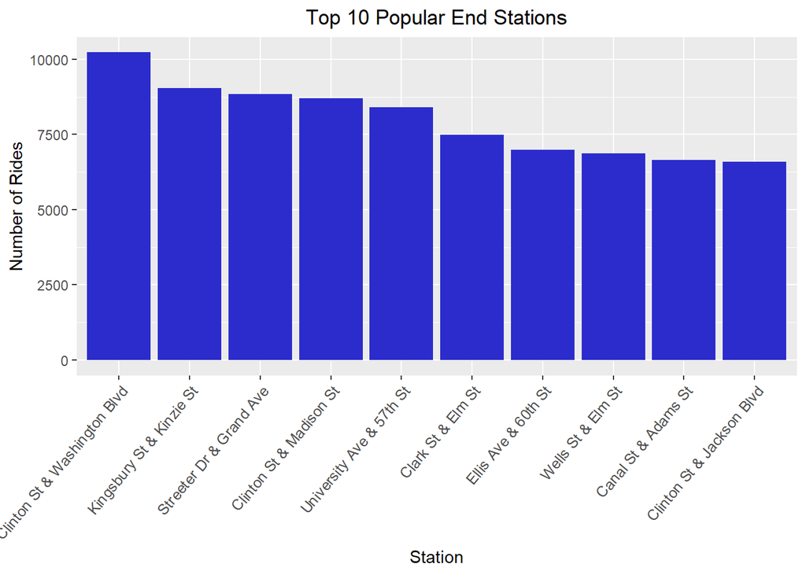

### Act: Recommendations based on analysis

- Targeted Marketing Campaigns
  - Since annual members have more total rides per day, Cyclistic should launch a targeted marketing campaign aimed at increasing the frequency of rides among casual riders. This can involve promotions or incentives to encourage casual riders to use the bike share more frequently.
  - **Recommendation #1: Offering a discount for multiple rides within a certain time frame.**
- Promotote Longer Rides
  - Although casual members have fewer total rides per day, since they have a higher average ride duration per day, Cyclistic should highlight the benefits of longer rides and the value proposition of an annual membership.
  - **Recommendation #2: Emphasize features like unlimited ride duration for members or exclusive access to certain routes or destinations.**
- Enhance User Experience at Popular Stations
  - Since the top 8 most popular start stations are the same as the top 8 most popular end stations, Cyclistic should focus on enhancing the user experience at these stations.
  - **Recommendation #3: Improve bike availability, optimize station layouts for easier access, and implement additional amenities or services to attract and retain users.**